# Data 624 Assignment 4

John Kellogg

3/6/2021

## Exercise 3.1

The UC Irvine Machine Learning Repository6 contains a data set related to glass identification. The data consist of 214 glass samples labeled as one of seven class categories. There are nine predictors, including the refractive index and percentages of eight elements: Na, Mg, Al, Si, K, Ca, Ba, and Fe.

```r
library(mlbench)
data(Glass)
str(Glass)
```

```
## 'data.frame':    214 obs. of  10 variables:
##  $ RI  : num  1.52 1.52 1.52 1.52 1.52 ...
##  $ Na  : num  13.6 13.9 13.5 13.2 13.3 ...
##  $ Mg  : num  4.49 3.6 3.55 3.69 3.62 3.61 3.6 3.61 3.58 3.6 ...
##  $ Al  : num  1.1 1.36 1.54 1.29 1.24 1.62 1.14 1.05 1.37 1.36 ...
##  $ Si  : num  71.8 72.7 73 72.6 73.1 ...
##  $ K   : num  0.06 0.48 0.39 0.57 0.55 0.64 0.58 0.57 0.56 0.57 ...
##  $ Ca  : num  8.75 7.83 7.78 8.22 8.07 8.07 8.17 8.24 8.3 8.4 ...
##  $ Ba  : num  0 0 0 0 0 0 0 0 0 0 ...
##  $ Fe  : num  0 0 0 0 0 0.26 0 0 0 0.11 ...
##  $ Type: Factor w/ 6 levels "1","2","3","5",..: 1 1 1 1 1 1 1 1 1 1 ...
```

### (a)

Using visualizations, explore the predictor variables to understand their distributions as well as the relationships between predictors.

```r
head(Glass)
```

```
##        RI    Na   Mg   Al    Si    K   Ca Ba   Fe Type
## 1 1.52101 13.64 4.49 1.10 71.78 0.06 8.75  0 0.00    1
## 2 1.51761 13.89 3.60 1.36 72.73 0.48 7.83  0 0.00    1
## 3 1.51618 13.53 3.55 1.54 72.99 0.39 7.78  0 0.00    1
## 4 1.51766 13.21 3.69 1.29 72.61 0.57 8.22  0 0.00    1
## 5 1.51742 13.27 3.62 1.24 73.08 0.55 8.07  0 0.00    1
## 6 1.51596 12.79 3.61 1.62 72.97 0.64 8.07  0 0.26    1
```

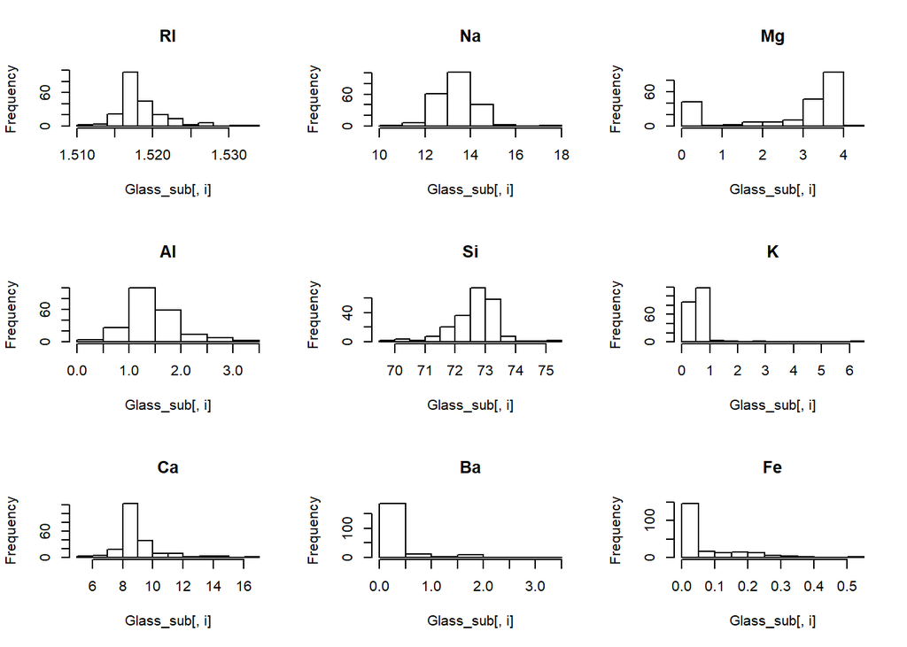

```r
Glass_sub <- subset(Glass, select = -Type)
predictors <- colnames(Glass)

par(mfrow = c(3,3))
for(i in 1:9) {
  hist(Glass_sub[,i],main = predictors[i])
}
```

- There is a lot of variation between the variables.
- Aluminum, Silicon, Sodium being the closest to normal
- Iron, Barium, Potassium appear to be the farthest from normal
- Magnesium is the only bipolar distribution

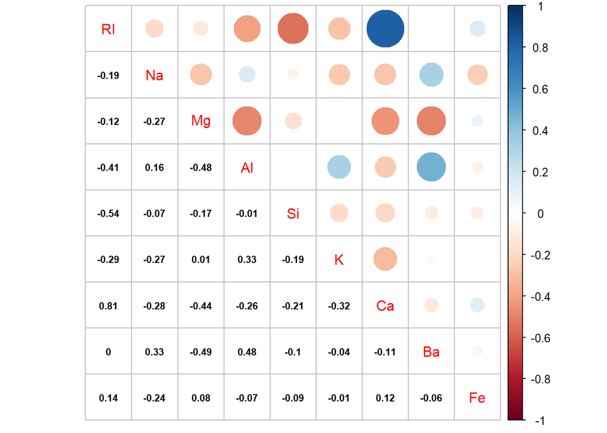

```r
corrplot.mixed(cor(Glass_sub[,1:9]), lower.col = "black", number.cex = .7)
```

### (b)

Do there appear to be any outliers in the data? Are any predictors skewed?

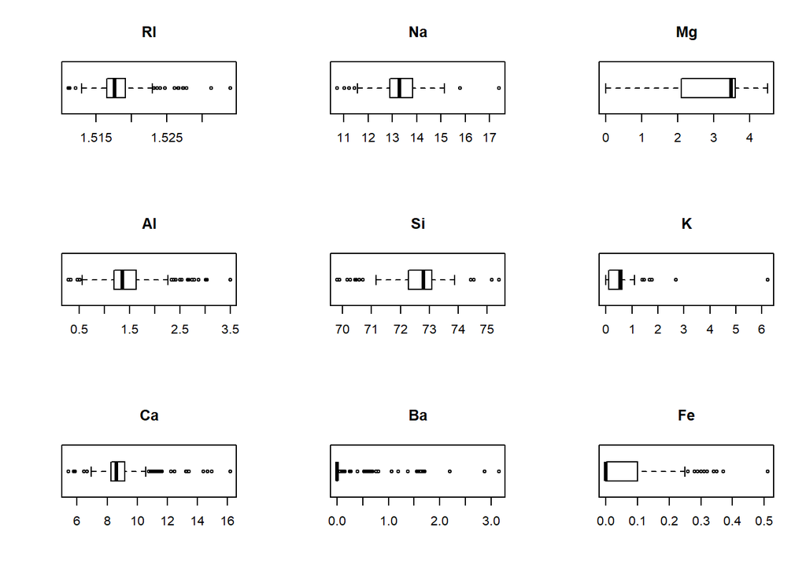

```r
Glass_gather <- Glass %>%
  pivot_longer(-Type, names_to = "predictors", values_to = "measurement", values_drop_na = TRUE) %>%
  mutate(predictors = as.factor(predictors))

par(mfrow = c(3,3))
for(i in 1:9) {
  boxplot(Glass_sub[,i],main = predictors[i], horizontal = TRUE)
}
```

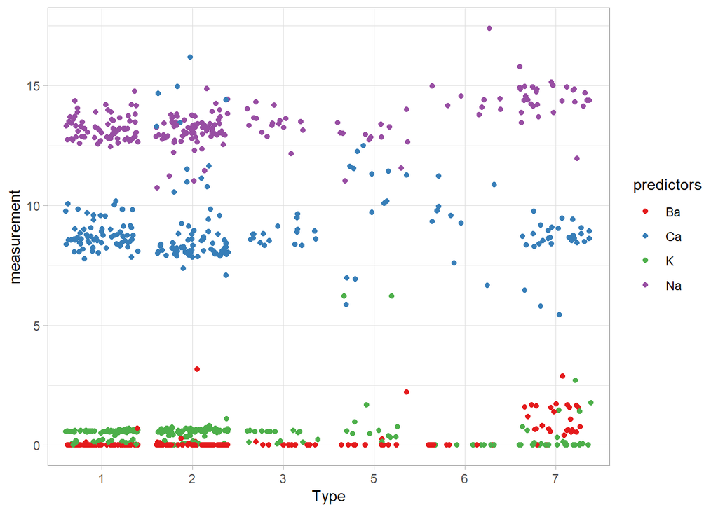

```r
Glass_gather %>%
  filter(predictors == 'Na'|predictors == 'K'|predictors == 'Ba'|predictors == 'Ca')%>%
  ggplot(aes(x=Type, y=measurement, color=predictors))+
  geom_jitter()+
  scale_color_brewer(palette = "Set1") +
  theme_light()
```

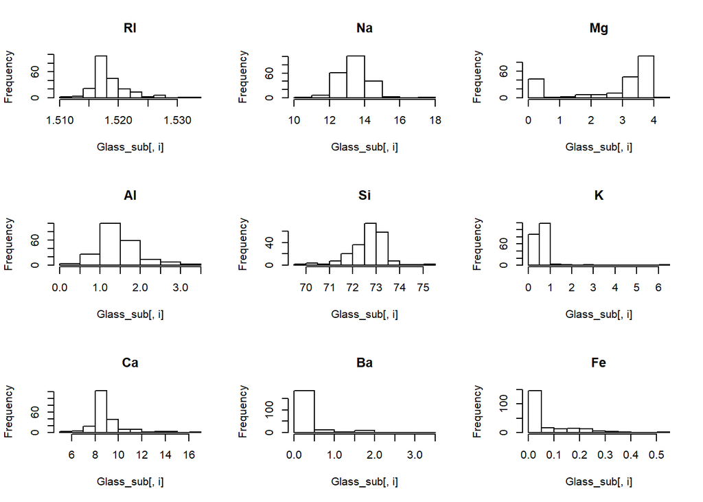

```r
par(mfrow = c(3,3))
for(i in 1:9) {
  hist(Glass_sub[,i],main = predictors[i])
}
```

### (c)

Are there any relevant transformations of one or more predictors that might improve the classification model?

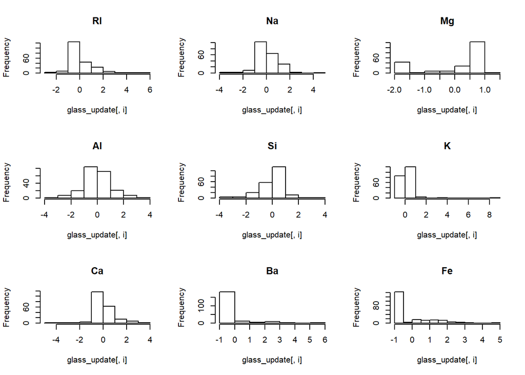

```r
glass_process <- preProcess(Glass, method=c('BoxCox', 'center', 'scale'))
glass_update<- predict(glass_process, Glass)

par(mfrow = c(3,3))
for(i in 1:9) {
  hist(glass_update[,i],main = predictors[i])
}
```

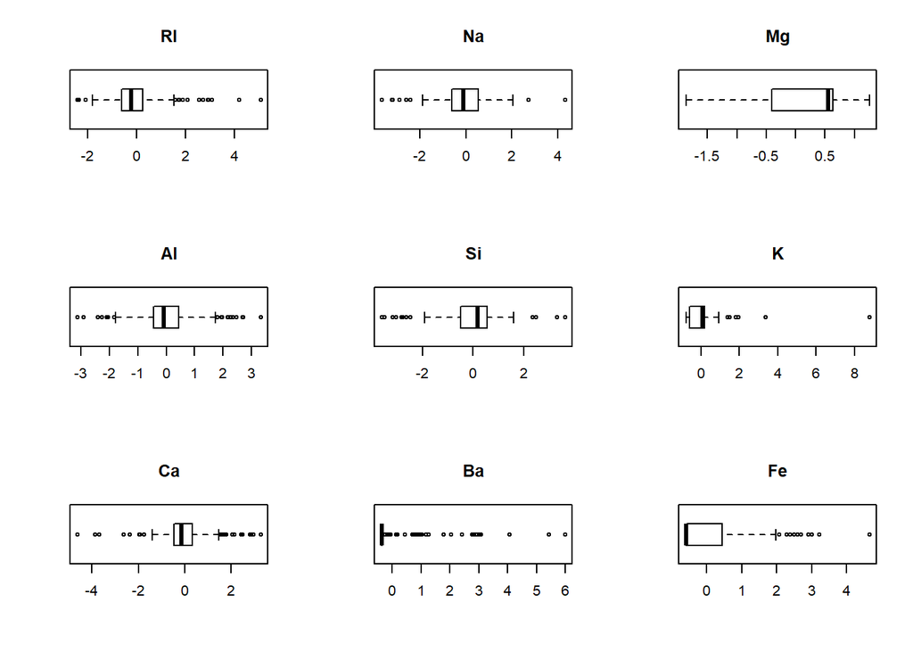

```r
par(mfrow = c(3,3))
for(i in 1:9) {
  boxplot(glass_update[,i],main = predictors[i], horizontal = TRUE)
}
```

## Exercise 3.2

The soybean data can also be found at the UC Irvine Machine Learning Repository. Data were collected to predict disease in 683 soybeans. The 35 predictors are mostly categorical and include information on the environmental conditions (e.g., temperature, precipitation) and plant conditions (e.g., left spots, mold growth). The outcome labels consist of 19 distinct classes.

### (a)

Investigate the frequency distributions for the categorical predictors. Are any of the distributions degenerate in the ways discussed earlier in this chapter?

```r
data("Soybean")
Soybean = Soybean
```

```r
nearZeroVar(Soybean)
```

```
## [1] 19 26 28
```

```r
names(Soybean[,nearZeroVar(Soybean)])
```

```
## [1] "leaf.mild" "mycelium"  "sclerotia"
```

```r
summary(Soybean[19])
```

```
##  leaf.mild
##  0   :535
##  1   : 20
##  2   : 20
##  NA's:108
```

```r
summary(Soybean[26])
```

```
##  mycelium
##  0   :639
##  1   :  6
##  NA's: 38
```

```r
summary(Soybean[28])
```

```
##  sclerotia
##  0   :625
##  1   : 20
##  NA's: 38
```

### (b)

Roughly 18% of the data are missing. Are there particular predictors that are more likely to be missing? Is the pattern of missing data related to the classes?

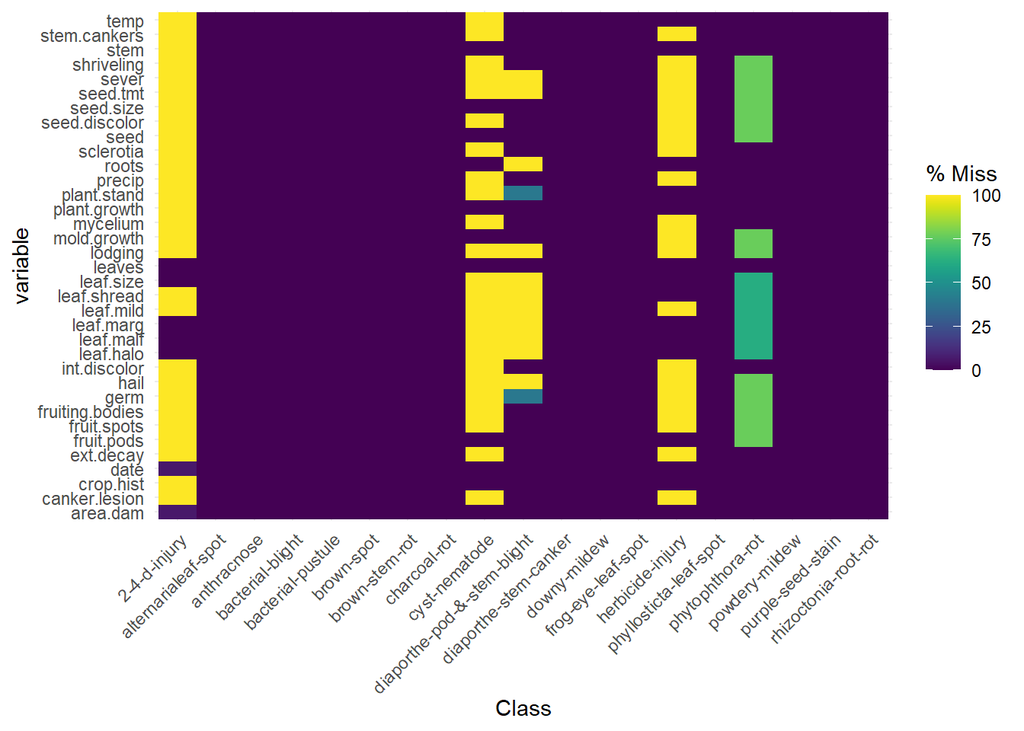

```r
Soybean %>%
  group_by(Class)%>%
  gg_miss_fct(Class)
```

- The Missing predictors to seem to be in specific variables.
  - 2-4-d-injury being the one with the most missing.

### (c)

Develop a strategy for handling missing data, either by eliminating predictors or imputation.

```r
#copy dataframe
Soybean_update <- Soybean

#rewrite dataframe so I control the formating
fwrite(Soybean,"soybean.temp")
Soybean_update <- fread("soybean.temp",colClasses = "character")

#updating all columns but class to numberic
Soybean_update <- Soybean_update %>%
  mutate_at(vars("date","plant.stand","precip","temp","hail","crop.hist","area.dam","sever","seed.tmt","germ","plant.growth","leaves","leaf.halo","leaf.marg","leaf.size","leaf.shread","leaf.malf","leaf.mild","stem","lodging","stem.cankers","canker.lesion","fruiting.bodies","ext.decay","mycelium","int.discolor","sclerotia","fruit.pods","fruit.spots","seed","mold.growth","seed.discolor","seed.size","shriveling","roots" ),as.numeric)

#setting all NA's to mean of column
Soybean_update <-Soybean_update %>%
  mutate_all(~ifelse(is.na(.x), mean(.x, na.rm = TRUE), .x))

summary(Soybean_update)
```

```
##     Class                date        plant.stand         precip
##  Length:683         Min.   :0.000   Min.   :0.0000   Min.   :0.000
##  Class :character   1st Qu.:2.000   1st Qu.:0.0000   1st Qu.:1.000
##  Mode  :character   Median :4.000   Median :0.0000   Median :2.000
##                     Mean   :3.554   Mean   :0.4529   Mean   :1.597
##                     3rd Qu.:5.000   3rd Qu.:1.0000   3rd Qu.:2.000
##                     Max.   :6.000   Max.   :1.0000   Max.   :2.000
##       temp            hail         crop.hist        area.dam
##  Min.   :0.000   Min.   :0.000   Min.   :0.000   Min.   :0.000
##  1st Qu.:1.000   1st Qu.:0.000   1st Qu.:1.000   1st Qu.:1.000
##  Median :1.000   Median :0.000   Median :2.000   Median :1.000
##  Mean   :1.182   Mean   :0.226   Mean   :1.885   Mean   :1.581
##  3rd Qu.:2.000   3rd Qu.:0.226   3rd Qu.:3.000   3rd Qu.:3.000
##  Max.   :2.000   Max.   :1.000   Max.   :3.000   Max.   :3.000
##      sever           seed.tmt           germ        plant.growth
##  Min.   :0.0000   Min.   :0.0000   Min.   :0.000   Min.   :0.0000
##  1st Qu.:0.0000   1st Qu.:0.0000   1st Qu.:1.000   1st Qu.:0.0000
##  Median :1.0000   Median :0.5196   Median :1.000   Median :0.0000
##  Mean   :0.7331   Mean   :0.5196   Mean   :1.049   Mean   :0.3388
##  3rd Qu.:1.0000   3rd Qu.:1.0000   3rd Qu.:2.000   3rd Qu.:1.0000
##  Max.   :2.0000   Max.   :2.0000   Max.   :2.000   Max.   :1.0000
##      leaves         leaf.halo       leaf.marg       leaf.size
##  Min.   :0.0000   Min.   :0.000   Min.   :0.000   Min.   :0.000
##  1st Qu.:1.0000   1st Qu.:0.000   1st Qu.:0.000   1st Qu.:1.000
##  Median :1.0000   Median :2.000   Median :0.000   Median :1.000
##  Mean   :0.8873   Mean   :1.202   Mean   :0.773   Mean   :1.284
##  3rd Qu.:1.0000   3rd Qu.:2.000   3rd Qu.:2.000   3rd Qu.:2.000
##  Max.   :1.0000   Max.   :2.000   Max.   :2.000   Max.   :2.000
##   leaf.shread       leaf.malf         leaf.mild           stem
##  Min.   :0.0000   Min.   :0.00000   Min.   :0.0000   Min.   :0.0000
##  1st Qu.:0.0000   1st Qu.:0.00000   1st Qu.:0.0000   1st Qu.:0.0000
##  Median :0.0000   Median :0.00000   Median :0.0000   Median :1.0000
##  Mean   :0.1647   Mean   :0.07513   Mean   :0.1043   Mean   :0.5562
##  3rd Qu.:0.1647   3rd Qu.:0.00000   3rd Qu.:0.0000   3rd Qu.:1.0000
##  Max.   :1.0000   Max.   :1.00000   Max.   :2.0000   Max.   :1.0000
##     lodging         stem.cankers  canker.lesion    fruiting.bodies
##  Min.   :0.00000   Min.   :0.00   Min.   :0.0000   Min.   :0.0000
##  1st Qu.:0.00000   1st Qu.:0.00   1st Qu.:0.0000   1st Qu.:0.0000
##  Median :0.00000   Median :0.00   Median :0.9798   Median :0.0000
##  Mean   :0.07473   Mean   :1.06   Mean   :0.9798   Mean   :0.1802
```

[output cut: 8 more lines]

```
##  Max.   :2.0000   Max.   :1.000000   Max.   :2.0000   Max.   :1.00000
##    fruit.pods      fruit.spots         seed         mold.growth
##  Min.   :0.0000   Min.   :0.000   Min.   :0.0000   Min.   :0.0000
##  1st Qu.:0.0000   1st Qu.:0.000   1st Qu.:0.0000   1st Qu.:0.0000
##  Median :0.0000   Median :0.000   Median :0.0000   Median :0.0000
##  Mean   :0.5042   Mean   :1.021   Mean   :0.1946   Mean   :0.1134
##  3rd Qu.:1.0000   3rd Qu.:1.021   3rd Qu.:0.1946   3rd Qu.:0.0000
##  Max.   :3.0000   Max.   :4.000   Max.   :1.0000   Max.   :1.0000
##  seed.discolor      seed.size         shriveling          roots
##  Min.   :0.0000   Min.   :0.00000   Min.   :0.00000   Min.   :0.0000
##  1st Qu.:0.0000   1st Qu.:0.00000   1st Qu.:0.00000   1st Qu.:0.0000
##  Median :0.0000   Median :0.00000   Median :0.00000   Median :0.0000
##  Mean   :0.1109   Mean   :0.09983   Mean   :0.06586   Mean   :0.1779
##  3rd Qu.:0.0000   3rd Qu.:0.00000   3rd Qu.:0.00000   3rd Qu.:0.0000
##  Max.   :1.0000   Max.   :1.00000   Max.   :1.00000   Max.   :2.0000
```